# k-mer distances

John Lees

14/02/2022

Please read the whole document before starting. You can use any programming language you wish, but I would recommend either R or python. This exercise shouldn’t take more than a few hours.

## Setup

Download the attached archive and extract it. If you don’t have it, you can download it again from here: https://drive.google.com/file/d/1uSlsylC3_hirTR1fTx9_NitwpGTPNZcY/view?usp=sharing

You should find the following files within:

```
R6.fa
TIGR4.fa
14412_3#82.contigs_velvet.fa
14412_3#84.contigs_velvet.fa
```

These are FASTA files, each of which contains the genome sequence of an isolate of *Streptococcus pneumoniae*. These files have header row(s) which begin with `>` and name the sequence that follows, then the nucleotides of the sequence (usually 70 characters to a line, but this can vary).

The first two sequences are ‘reference’ sequences, and have the whole genome resolved to a single sequence entry which represents the entire chromosome. In reality this chromosome is circular, but in the file it is linear (i.e. the ends don’t join up), but you can ignore this in this complication in this exercise.

The second two sequences are ‘draft’ sequences, assembled from shotgun sequencing runs. Though the actual genome is still a single circular chromosome, the nature of the short read technology used for sequencing means it wasn’t possible to reconstruct a single continuous sequence for the whole genome. The genome is therefore split into multiple unordered ‘contigs’, each with their own header. Practically, this means you need to take care not to include the headers as sequence, and not read sequence across contig boundaries.

You could write your own code to read FASTA files, but a sequence file processing package may be helpful e.g. `seqinr` (in R), or the `SeqIO` module in Biopython (in python).

## Task

You are going to develop a simple implementation of the MinHash algorithm, which will let you quickly calculate genetic distances between these samples.

### Reading k-mers

First, you need to split the genomes up into smaller parts which can be compared. A very common way to do this is using k-mers, which are substrings of length $k$. Throughout this exercise we will use $k = 14$. To demonstrate, the sequence:

```
TTGAAAGAAAAACAATTTTG
```

contains the following 14-mers:

```
TTGAAAGAAAAACA
TGAAAGAAAAACAA
GAAAGAAAAACAAT
AAAGAAAAACAATT
AAGAAAAACAATTT
AGAAAAACAATTTT
GAAAAACAATTTTG
```

**Step 1**: Write code to read in the DNA sequence from the above FASTA files, and count the occurences of 14-mers in each of the four files (storing these in a dictionary or similar). You may find it useful to load the whole genome as a string, and then treat it as an array of characters to run through the substrings within it.

For example, using an array `genome` which contained the whole sequence in python, `genome[0:14]` would give you the first 14-mer, `genome[1:15]` would give you the second 14-mer and so on. Alternatively, you can ‘roll’ through the string by starting with the first 14-mer, then adding the next base on and subtracting the first base off the start to get each subsequent 14-mer.

### Simple Jaccard distances

A simple distance between a pair of these genomes can be calculated from the Jaccard index $J$, which is mathematically defined between two sequences $A$ and $B$ by:
$$J(A, B) = \frac{|A \cap B|}{|A \cup B|}$$
which is the size of the intersection (i.e. the number of 14-mers in both sequences $A$ and $B$) over the size of the union (i.e. the total number of unique 14-mers in both $A$ and $B$; this can also be calculated by adding the total number of 14-mers in both $A$ and $B$, and subtracting the size of the intersection).

The following Venn diagram may help you visualise what the intersection and union are, if you have not come across them before:

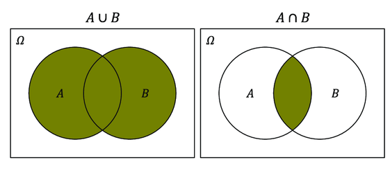

For example, if sequence $A$ has the following seven 14-mers:

```
TTGAAAGAAAAACA
TGAAAGAAAAACAA
GAAAGAAAAACAAT
AAAGAAAAACAATT
AAGAAAAACAATTT
AGAAAAACAATTTT
GAAAAACAATTTTG
```

and sequence $B$ has the following seven 14-mers:

```
TTGAAAGAAAAACA
TGAAAGAAAAACAA
GAAAGAAAAACAAT
AAAGAAAAACAATT
GAAAAACAATTTTG
CTCGATCCATGTAT
TCGATCCATGTATG
```

then $|A \cap B| = 5$, $|A \cup B| = 9$, $J(A, B) = \frac{5}{9}$. The Jaccard distance is $1 - J(A, B) = \frac{4}{9}$.

**Step 2**: Using your dictionaries of 14-mer counts, write code which calculates the Jaccard distance between two of the input samples. You should ignore the actual values of the counts, and simply take any 14-mer which appears once or more as ‘present’. Most will appear exactly once.

### MinHash Jaccard distances

For these sequences there are around 2 million 14-mers, which makes comparing them quite slow. A possible improvement is to use the MinHash algorithm. Broadly, this takes an unbiased sample of the 14-mers and calculates the Jaccard distance from this smaller subset.

First a ‘sketch’ is created using a [hash function](https://en.wikipedia.org/wiki/Hash_function). Hash functions simply take data and map it to an integer within a specified range, and common implementations include MurmurHash3 and xxhash. Using each 14-mer as an input string, a hash is applied to map it to an integer (sometimes represented as a hex string such as `9dc17945`). You might find these hex strings familiar from git commit IDs, which calculates a hash function of the code to produce a hex string representing the commit.

**Step 3**: Find an implementation of a hash function and import it into your code. Calculate the hash of some example 14-mers, and confirm that the same 14-mer input maps to the same integer output.

An example of how to do this in R could be:

```r
library(digest)

# some 14-mers for this example
kmers <- c("TTGAAAGAAAAACA",
           "TGAAAGAAAAACAA",
           "GAAAGAAAAACAAT",
           "AAAGAAAAACAATT",
           "AAGAAAAACAATTT",
           "AGAAAAACAATTTT",
           "GAAAAACAATTTTG")

# calculate a hash of the first k-mer, this comes back as a hex string. You could convert this to an integer (be aware this may be difficult in R as integers are 32-bits), but just using these hex strings directly for the steps below will work just as well
hash1 <- digest(kmers[1], algo = "murmur32", serialize = F, seed = 0)
hash1
```

```
## [1] "9dc17945"
```

```r
# Run on all the k-mers
hash_run1 <- unlist(lapply(kmers, digest, algo = "murmur32", serialize = F, seed = 0))
hash_run1
```

```
## [1] "9dc17945" "0c3c4207" "5f658cdc" "4a0e314c" "bc4f8b82" "6cf3f199" "e877e933"
```

```r
# Confirm the same hashes are generated on repeated runs (so they are comparable between samples)
hash_run2 <- unlist(lapply(kmers, digest, algo = "murmur32", serialize = F, seed = 0))
all(hash_run1 == hash_run2)
```

```
## [1] TRUE
```

A sketch is then defined by:

1. Converting all 14-mers from the genome into integers using a hash function.
2. Sorting these hashes
3. Taking the smallest $s$ hashes, where $s = 1000$ is the ‘sketch size’. This can be made larger or smaller, but for this purpose we’ll use a fixed value of 1000.

**Step 4**: Make a sketch of each of the input sequences by following the steps above: mapping any present 14-mers (ignoring their actual count as before) to integers using a hash function, then taking the lowest 1000 values and storing these in a list/array. Save your sketches for each input sequence: either as a text file, or some other representation.

The Jaccard distance can now be approximated by again calculating the sizes of the intersection and union, but using the sketches (i.e. the 1000 hashes) instead of all of the 14-mers.

**Step 5**: For each pair of inputs, load their sketches, and calculate their Jaccard distance using the sizes of the intersection and the union of the saved hash values.

### Comparing isolates (bonus)

If you have time:

- How do the MinHash distances compare to the full distances? What if you change the sketch size?
- Use your distances to make a neighbour-joining tree of the four isolates. How are they related? Does this change with the two different distances you have computed?

## Guidance

- Feel free to use external packages in your code if you wish (this may be especially useful for reading fasta files, using a hash function, and making neighbour-joining trees).
- Don’t worry about the speed/efficiency of your code, just get something that works.
- If you can’t do a step, or can’t do it fully, skip it and proceed to the next step where possible.
- Focus on getting the code to work for the two reference sequences first, and if that works then consider the draft sequences too.
- Pay attention to commenting your code and generally making it understandable to other people, so that we can talk through it.
- Put your code on github (or similar) and share the repository with me ahead of our meeting.